# Planejamento experimental e Análise de dados agronômicos

José Tiago Barroso Chagas

## Apresentação

[figure not shown]

*Engenheiro agronômo (**UFCA**- 2018)*

*Mestre em genética e melhoramento de plantas (**UENF**-2020)*

*Doutor em genética e melhoramento (**UFV**- 2024)*

*Pesquisador de pós doutorado (**UFV**- Atual)*

## Sumário

- Princípios da experimentação agrícola
- Planejamento de Experimentos agronômicos
- Equações de Modelos Mistos
- Análise de variância individual
- Análise de variância conjunta
- Predição de valores genotípicos
- Análise de Fatores
- Índices de seleção

## Princípios da Experimentação agrícola

- Repetição
- Casualização
- Controle local

```
DIC - 5trat*3rep
```

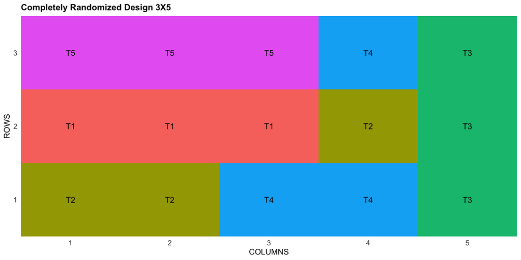

```
DBC - 5trat*3rep
```

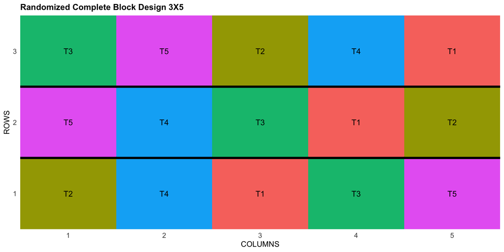

## Planejamento de Experimentos agronômicos

- Experimentos com grande número de tratamentos para os blocos casualizados em DBC
- **k** Tratamentos divididos em **k** blocos (ktrat*kblocos)
- Látice quadrado (9trat/k3/rep3)

```
LÁTICE
```

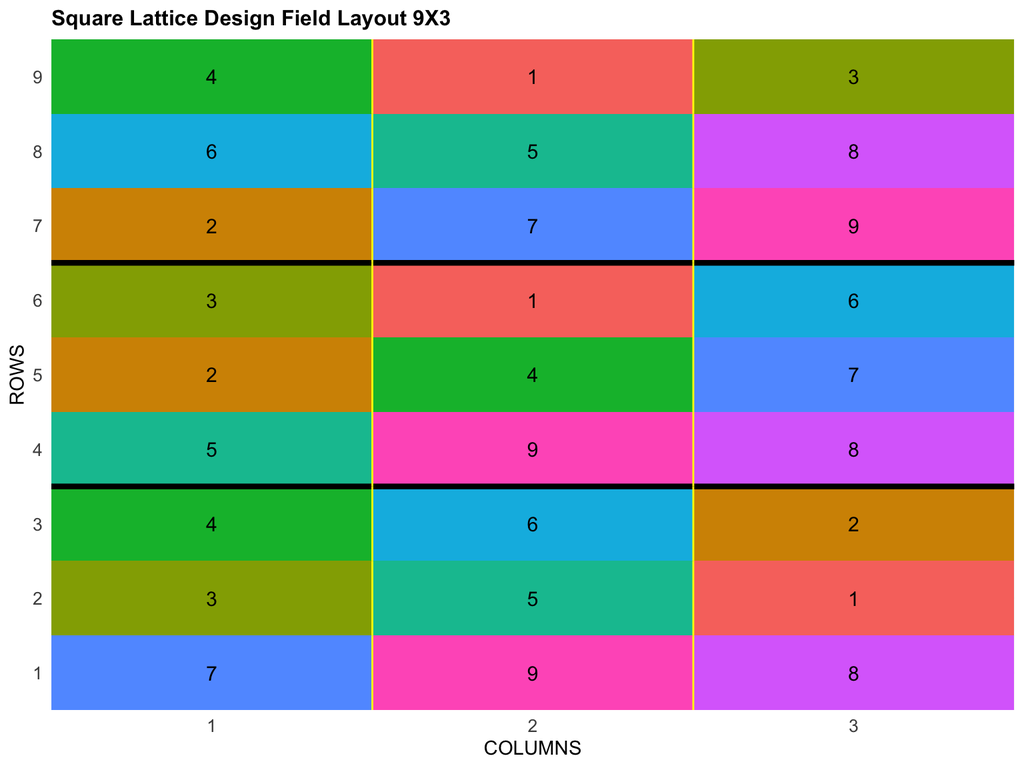

```
  ID LOCATION PLOT REP IBLOCK UNIT ENTRY TREATMENT
1  1  COIMBRA 1001   1      1    1     7       G-7
2  2  COIMBRA 1002   1      1    2     3       G-3
3  3  COIMBRA 1003   1      1    3     4       G-4
```

## Planejamento de Experimentos agronômicos

- Experimento com restrição quanto à disponibilidade de sementes e/ou volume grande de tratamentos para a área experimental
- Delineamento em blocos aumentados

(30gen/3test/k6)

```
  ID  EXPT LOCATION YEAR PLOT ROW COLUMN CHECKS BLOCK ENTRY TREATMENT
1  1 Expt1  COIMBRA 2025 1001   1      1      1     1     3       CH3
2  2 Expt1  COIMBRA 2025 1002   1      2      1     1     2       CH2
3  3 Expt1  COIMBRA 2025 1003   1      3      0     1    23       G23
```

```
DBA
```

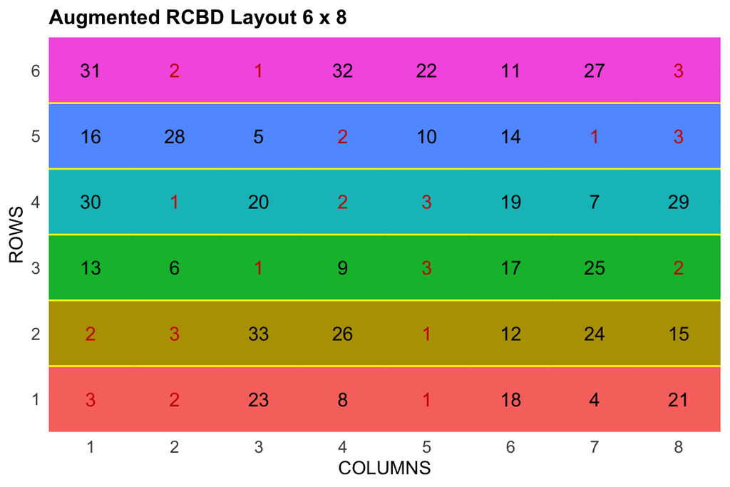

## Equações de modelos mistos

Charles R. Henderson (1953) (melhorista animal) propôs as equações de modelos mistos

As quais possibilitaram obter BLUPs dos efeitos aleatórios (Melhor preditor linear não viesado) e estimadores de máxima verossimilhança dos efeitos fixos de $\beta$.

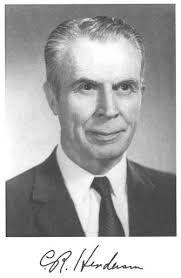

## Equações de modelos mistos

$$\textbf{y} = \mathbf{X}\beta + \mathbf{Z}u+ \mathbf{e}$$

$$\begin{align*}
\begin{bmatrix}
\mathbf{X}'\mathbf{X} & \mathbf{X}'\mathbf{Z} \\
\mathbf{Z}'\mathbf{X} & \mathbf{Z}'\mathbf{Z} + \lambda \mathbf{K}^{-1}
\end{bmatrix}
\begin{bmatrix}
\mathbf{\hat{b}} \\
\mathbf{\hat{u}}
\end{bmatrix}
&=
\begin{bmatrix}
\mathbf{X}'\mathbf{y} \\
\mathbf{Z}'\mathbf{y}
\end{bmatrix}
\end{align*}$$

### Máxima verossimilhança restrita (REML-Restricted maximum likelihood)

Patterson and Thompson (1971)

Função de densidade de probabilidade normal

$$f(x)= \frac{1}{\sigma \sqrt{2\pi}}e^{-\frac{1}{2}(\frac{x-\mu}{\sigma})^2}$$

A função de máxima verossimilhança buscar a otimização dos valores da média $\mu$ e variância $\sigma$, dado as observações e considerando distribuição normal.

Neste exemplo consideramos 100 valores aleatórios gerados de uma distribuição normal com média 10 ($\mu$) e desvio padrão $\sqrt{10}$ ($\sigma$)

```
head de valores amostrados
```

```
[1] 13.105260 11.482207  9.658565  9.326820 13.662229 14.086785
```

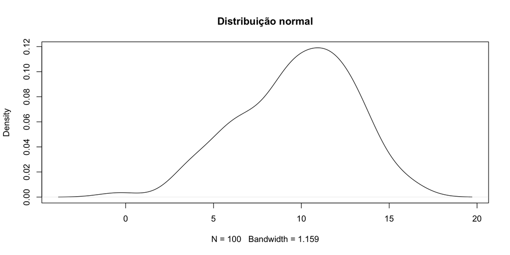

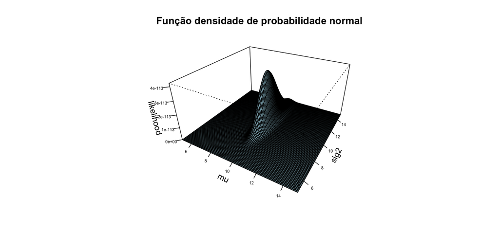

## Equações de modelos mistos

BLUE (Melhor estimador linear não viesado - efeitos fixos)

BLUP (Melhor preditor linear não viesado - efeitos aleatórios)

C. R. Henderson (1975)

### Simulação de dados fenotípicos - Exemplo

Traits: Produtividade de grãos e altura de planta

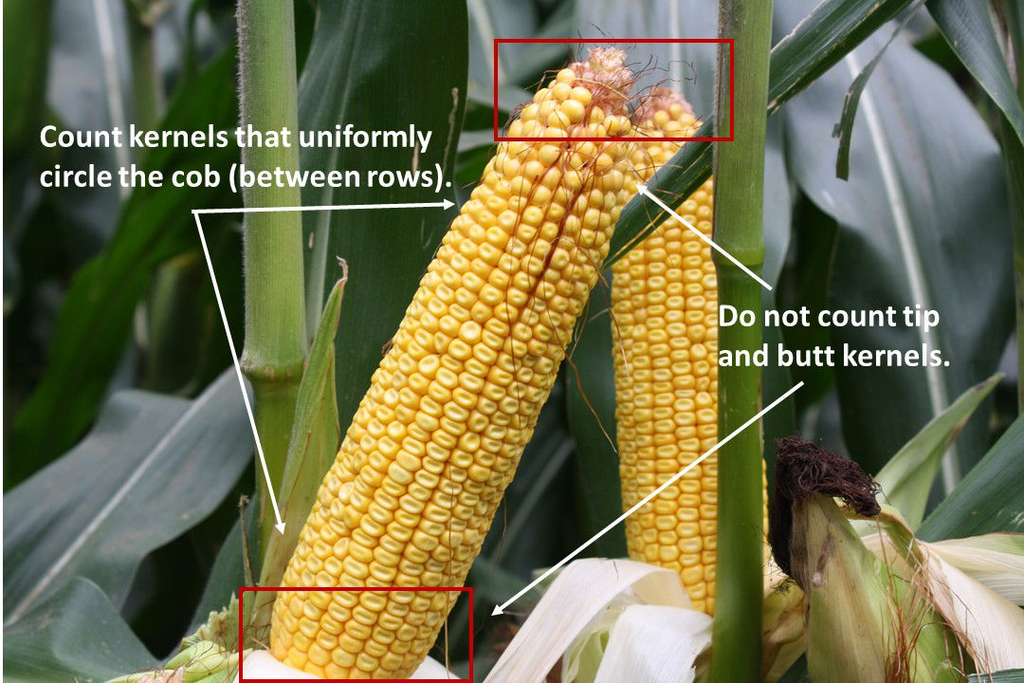

Fonte: Bayer crop science

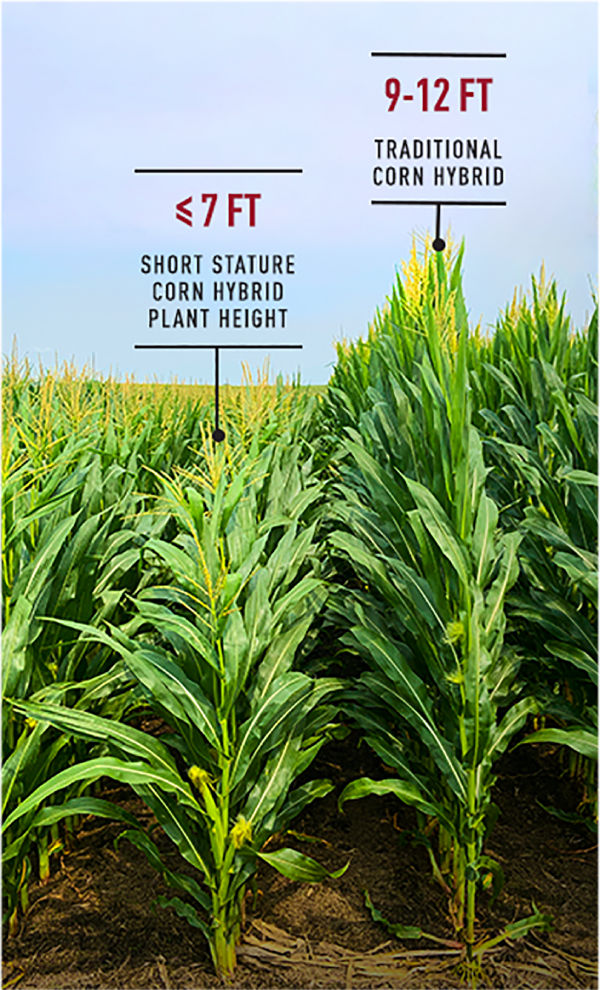

Fonte: Bayer crop science

**2 características; 100 genótipos; 2 blocos**

```
Variâncias residuais Trait per environment -
    c(Yld:E1, Yld:E2, Yld:E3, Pht:E1, Pht:E2, Pht:E3
```

```
[1]  0.20  0.28  0.14 15.10  8.50 11.70
```

```
Correlação dos erros devido tendências espaciais
```

```
     1    2
1 1.00 0.49
2 0.49 1.00
```

```
Correlação dos erros devido causas não conhecidas
    (Caminhamento,máquinas e implementos)
```

```
     1    2
1 1.00 0.02
2 0.02 1.00
```

```
Banco de dados simulado de Milho
```

```
'data.frame':   200 obs. of  8 variables:
 $ env  : Factor w/ 1 level "1": 1 1 1 1 1 1 1 1 1 1 ...
 $ block: Factor w/ 2 levels "1","2": 1 1 1 1 1 1 1 1 1 1 ...
 $ col  : Factor w/ 10 levels "1","2","3","4",..: 1 1 1 1 1 1 1 1 1 1 ...
 $ row  : Factor w/ 20 levels "1","2","3","4",..: 1 2 3 4 5 6 7 8 9 10 ...
 $ id   : Factor w/ 100 levels "1","2","3","4",..: 39 4 77 14 49 62 47 94 40 63 ...
 $ rep  : Factor w/ 2 levels "1","2": 1 1 1 1 1 1 1 1 1 1 ...
 $ GY   : num  5.51 5.7 5.8 5.17 5.32 ...
 $ PH   : num  230 230 230 232 239 ...
```

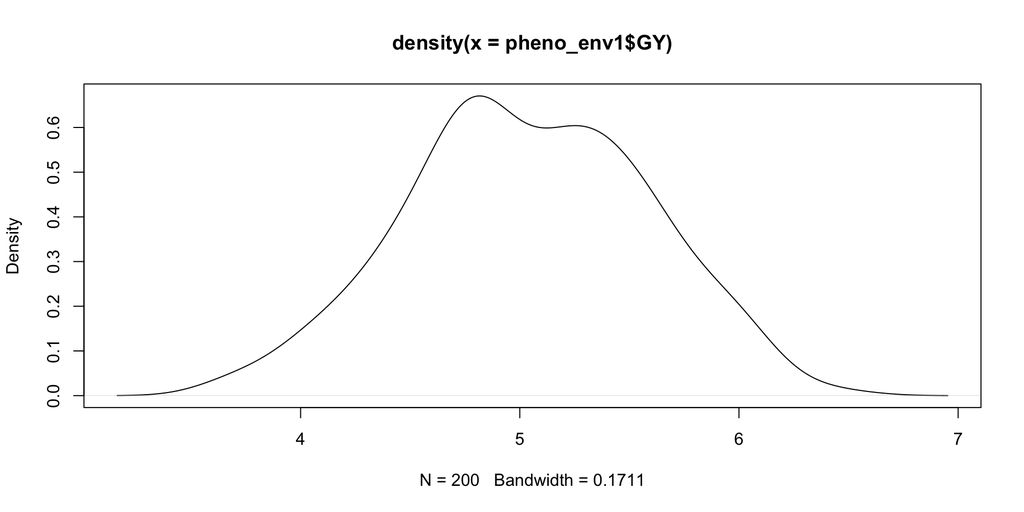

```
Solving mixed models with RHS
```

```
[1] 5.513532 5.703086 5.796593 5.168647 5.323202 5.033188
```

### Resolvendo as equações de modelos mistos (RHS) - GY

$$\begin{align*}
\begin{bmatrix}
\mathbf{X}'\mathbf{X} & \mathbf{X}'\mathbf{Z} \\
\mathbf{Z}'\mathbf{X} & \mathbf{Z}'\mathbf{Z} + \lambda \mathbf{K}^{-1}
\end{bmatrix}
\begin{bmatrix}
\mathbf{\hat{b}} \\
\mathbf{\hat{u}}
\end{bmatrix}
&=
\begin{bmatrix}
\mathbf{X}'\mathbf{y} \\
\mathbf{Z}'\mathbf{y}
\end{bmatrix}
\end{align*}$$

```
X matrix - Efeitos fixos
```

```
  block1 block2
1      1      0
2      1      0
3      1      0
4      1      0
5      1      0
6      1      0
```

```
Z matrix - Efeitos aleatórios
```

```
   id1 id2 id3 id4 id5 id6 id7 id8 id9 id10
1    0   0   0   0   0   0   0   0   0    0
2    0   0   0   1   0   0   0   0   0    0
3    0   0   0   0   0   0   0   0   0    0
4    0   0   0   0   0   0   0   0   0    0
5    0   0   0   0   0   0   0   0   0    0
6    0   0   0   0   0   0   0   0   0    0
7    0   0   0   0   0   0   0   0   0    0
8    0   0   0   0   0   0   0   0   0    0
9    0   0   0   0   0   0   0   0   0    0
10   0   0   0   0   0   0   0   0   0    0
```

```
Phenotypic data
```

```
   env block col row id rep       GY       PH
1    1     1   1   1 39   1 5.513532 230.2357
2    1     1   1   2  4   1 5.703086 230.2436
3    1     1   1   3 77   1 5.796593 230.4429
4    1     1   1   4 14   1 5.168647 231.6617
5    1     1   1   5 49   1 5.323202 238.9142
6    1     1   1   6 62   1 5.033188 233.4361
7    1     1   1   7 47   1 5.969180 227.9464
8    1     1   1   8 94   1 5.296897 233.5849
9    1     1   1   9 40   1 3.751499 226.4649
10   1     1   1  10 63   1 4.588704 235.6345
```

```
Error variance
```

```
[1] 0.2075
```

```
Genotypic variance
```

```
[1] 0.0948
```

```
Lambda
```

```
[1] 2.188819
```

```
XpX
```

```
       block1 block2
block1    100      0
block2      0    100
```

```
XpZ
```

```
       id1 id2 id3 id4 id5
block1   1   1   1   1   1
block2   1   1   1   1   1
```

```
ZpX
```

```
    block1 block2
id1      1      1
id2      1      1
id3      1      1
id4      1      1
id5      1      1
id6      1      1
```

```
ZpZ
```

```
    id1 id2 id3 id4 id5
id1   2   0   0   0   0
id2   0   2   0   0   0
id3   0   0   2   0   0
id4   0   0   0   2   0
id5   0   0   0   0   2
```

```
Xpy
```

```
           [,1]
block1 498.0205
block2 509.2963
```

```
Zpy
```

```
         [,1]
id1  8.834306
id2 10.478144
id3 11.530348
id4 10.042302
id5  9.734658
id6  9.007352
```

```
LHS
```

```
       block1 block2      id1      id2      id3
block1    100      0 1.000000 1.000000 1.000000
block2      0    100 1.000000 1.000000 1.000000
id1         1      1 4.188819 0.000000 0.000000
id2         1      1 0.000000 4.188819 0.000000
id3         1      1 0.000000 0.000000 4.188819
```

```
RHS
```

```
             [,1]
block1 498.020468
block2 509.296324
id1      8.834306
id2     10.478144
id3     11.530348
id4     10.042302
```

```
Solutions solve(LHS) %*% RHS
```

```
               [,1]
block1  4.980204681
block2  5.092963242
id1    -0.295754501
id2     0.096680330
id3     0.347873860
id4    -0.007368719
```

### Resolvendo as equações de modelos mistos (LME4) - GY

```
Solving mixed models with package LME4
```

```
Linear mixed model fit by REML ['lmerMod']
Formula: GY ~ rep + (1 | id)
   Data: pheno_env1

REML criterion at convergence: 320.2

Scaled residuals:
     Min       1Q   Median       3Q      Max
-2.15158 -0.56334  0.05882  0.58978  2.09491

Random effects:
 Groups   Name        Variance Std.Dev.
 id       (Intercept) 0.1010   0.3178
 Residual             0.1982   0.4451
Number of obs: 200, groups:  id, 100

Fixed effects:
            Estimate Std. Error t value
(Intercept)  4.98020    0.05469  91.058
rep2         0.11276    0.06295   1.791

Correlation of Fixed Effects:
     (Intr)
rep2 -0.576
```

RHS

| x |
| --- |
| -0.2957545 |
| 0.0966803 |
| 0.3478739 |
| -0.0073687 |
| -0.0808127 |
| -0.2544430 |

LME4

|  | x |
| --- | --- |
| id.(Intercept)1 | -0.3126610 |
| id.(Intercept)2 | 0.1022069 |
| id.(Intercept)3 | 0.3677597 |
| id.(Intercept)4 | -0.0077899 |
| id.(Intercept)5 | -0.0854323 |
| id.(Intercept)6 | -0.2689879 |

## Análise conjunta

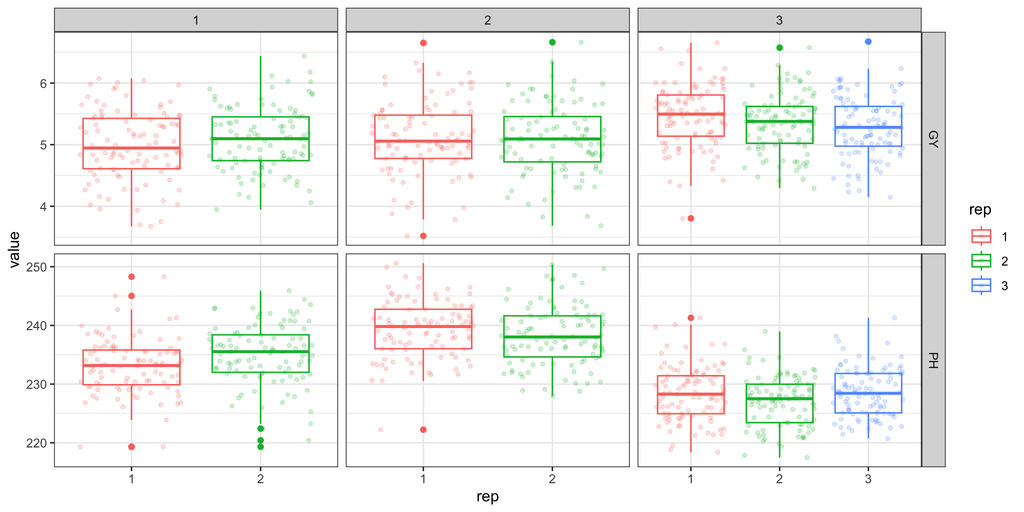

$$\mathbf{y} = \mathbf{X}_1\mathbf{e} + \mathbf{X}_2\mathbf{be} + \mathbf{Z}_1\mathbf{g} + \mathbf{Z}_2\mathbf{ge} + \mathbf{\epsilon}$$

$[\mathbf{g}\sim N(0,\sigma_g^2\mathbf{I}_n)]$ e $[\mathbf{ge}\sim N(0,\sigma_{ge}^2\mathbf{I}_{np})]$, onde n é o número de genótipos e p é o número de ambientes.

**2 características; 100 genótipos; 2-3 blocos; 3 ambientes**

Testar os efeitos de genótipo e da interação genótipo x ambiente para as características avaliadas.
$$LRT = -2(LogL_-LogL_{r})$$
onde $LogL$ é o ponto de máxima da função de verossimilhança residual do modelo completo e $LogL_{r}$ é o mesmo para o modelo reduzido.

```
Análise de variância conjunta - GY
```

```
Linear mixed model fit by REML ['lmerMod']
Formula: GY ~ env + rep:env + (1 | id) + (1 | id:env)
   Data: pheno_df

REML criterion at convergence: 1063.2

Scaled residuals:
     Min       1Q   Median       3Q      Max
-2.67400 -0.55510  0.01111  0.57905  2.30558

Random effects:
 Groups   Name        Variance Std.Dev.
 id:env   (Intercept) 0.09360  0.3059
 id       (Intercept) 0.01043  0.1021
 Residual             0.18065  0.4250
Number of obs: 700, groups:  id:env, 300; id, 100

Fixed effects:
            Estimate Std. Error t value
(Intercept)  4.98020    0.05336  93.340
env2         0.13322    0.07406   1.799
env3         0.48945    0.07406   6.609
env1:rep2    0.11276    0.06011   1.876
env2:rep2   -0.02553    0.06011  -0.425
env3:rep2   -0.12331    0.06011  -2.051
env3:rep3   -0.19016    0.06011  -3.164

Correlation of Fixed Effects:
          (Intr) env2   env3   env1:2 env2:2 env3:2
env2      -0.694
env3      -0.694  0.500
env1:rep2 -0.563  0.406  0.406
env2:rep2  0.000 -0.406  0.000  0.000
env3:rep2  0.000  0.000 -0.406  0.000  0.000
env3:rep3  0.000  0.000 -0.406  0.000  0.000  0.500
fit warnings:
fixed-effect model matrix is rank deficient so dropping 2 columns / coefficients
```

```
LRT GxE effect - Trait GY
```

```
[1] 43.31988
```

```
Data: pheno_df
Models:
mmcr: GY ~ env + rep:env + (1 | id)
mmc: GY ~ env + rep:env + (1 | id) + (1 | id:env)
     npar    AIC    BIC  logLik -2*log(L)  Chisq Df Pr(>Chisq)
mmcr    9 1096.1 1137.0 -539.03    1078.1
mmc    10 1054.3 1099.8 -517.15    1034.3 43.758  1  3.717e-11 ***
---
Signif. codes:  0 '***' 0.001 '**' 0.01 '*' 0.05 '.' 0.1 ' ' 1
```

LME4 - g x e

|  | (Intercept) |
| --- | --- |
| id:env.1:1 | -0.2994339 |
| id:env.1:2 | -0.0883629 |
| id:env.1:3 | 0.1092676 |
| id:env.2:1 | 0.0992936 |
| id:env.2:2 | -0.0491773 |
| id:env.2:3 | 0.0160696 |

LME4 - g

|  | (Intercept) |
| --- | --- |
| id.1 | -0.0310489 |
| id.2 | 0.0073780 |
| id.3 | 0.0317793 |
| id.4 | -0.0026264 |
| id.5 | 0.0316266 |
| id.6 | -0.0007239 |

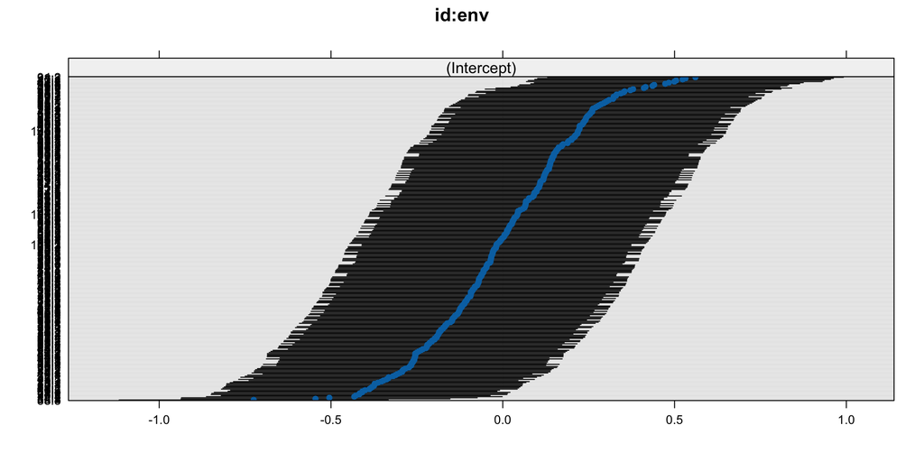

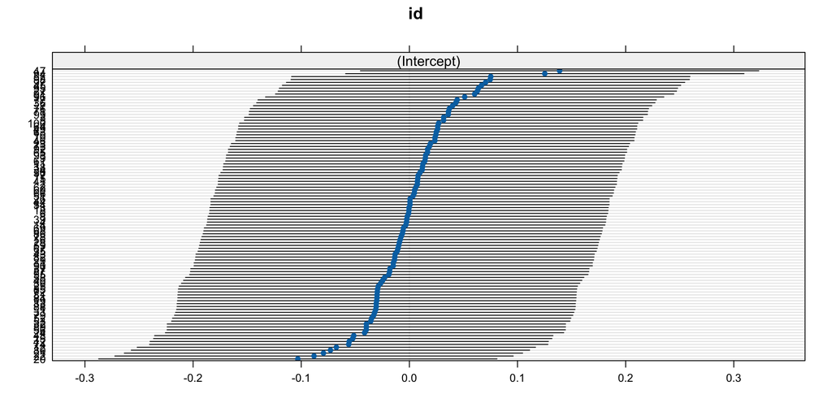

## Índice de Seleção

Diversos índices de seleção foram propostos com e sem restrições (Smith (1936) & Hazel (1943) ; Kempthorne and Nordskog (1959))

Neste curso abordaremos o índice de seleção da *análise de fatores e desenho da distância genótipo ideótipo* Rocha, Machado, and Carneiro (2018).

## Análise de Fatores

Considerando o dataset simulado de milho (2 traits * 3 ambientes)

Para proceder análise fatorial, deve-se realizar a análise de correlação de pearson entre pares de variáveis e criar a matriz de correlações.

```
Blups per trait:env
```

```
          GY_1        GY_2         GY_3       PH_1       PH_2       PH_3
1 -0.299433931 -0.08836286  0.109267596 -0.7960276 -3.2359131  1.5381855
2  0.099293639 -0.04917734  0.016069572 -2.6922993 -2.2370177  1.3938318
3  0.354614536  0.04186552 -0.111398567  0.7017383 -0.4216252  1.2066291
4 -0.006517491 -0.23820750  0.221164735 -3.2523328 -1.3943519 -0.1705401
5 -0.102230756  0.26035403  0.125588089 -1.4563768 -3.3728975  1.4816980
6 -0.270834073  0.26110773  0.003232461 -7.0252473 -0.8419086  2.4660021
```

```
Blups per trait:env standarized
```

```
         GY_1       GY_2        GY_3       PH_1       PH_2        PH_3
1 -1.37867867 -0.3996783  0.49698215 -0.4213632 -1.5317044  0.80693911
2  0.45717605 -0.2224364  0.07308928 -1.4251213 -1.0588819  0.73121050
3  1.63274581  0.1893639 -0.50667445  0.3714528 -0.1995743  0.63300313
4 -0.03000838 -1.0774477  1.00592425 -1.7215651 -0.6600100 -0.08946613
5 -0.47069937  1.1776197  0.57121270 -0.7709074 -1.5965453  0.77730550
6 -1.24699682  1.1810288  0.01470221 -3.7186910 -0.3985135  1.29367592
```

### Matriz de correlações

```
            GY_1        GY_2        GY_3        PH_1       PH_2        PH_3
GY_1  1.00000000 -0.05369986 -0.15382851  0.09624741  0.1535808 -0.03312696
GY_2 -0.05369986  1.00000000  0.04461362 -0.08982962  0.2295911  0.14690621
GY_3 -0.15382851  0.04461362  1.00000000  0.09267733 -0.2505011  0.38971600
PH_1  0.09624741 -0.08982962  0.09267733  1.00000000  0.1306623 -0.26498653
PH_2  0.15358083  0.22959111 -0.25050112  0.13066234  1.0000000 -0.34163029
PH_3 -0.03312696  0.14690621  0.38971600 -0.26498653 -0.3416303  1.00000000
```

Correlações próximas de zero propiciam a extração de fatores diferentes. Representar as correlações entre os traits por meio de variáveis latentes (fatores).

### Autovalores

Determinação dos autovalores pela seguinte equação:

$$[\det(\lambda^².I-\rho) = 0]$$

Multiplicado por uma matriz identidade diminuida da matriz de correlações $\rho$

$$\begin{bmatrix}
\lambda^2 & 0 & 0 & \cdots & 0 \\
0 & \lambda^2 & 0 & \cdots & 0 \\
0 & 0 & \lambda^2 & \cdots & 0 \\
\vdots & \vdots & \vdots & \ddots & \vdots \\
0 & 0 & 0 & \cdots & \lambda^2
\end{bmatrix}
\begin{bmatrix}
\rho_{11} & \rho_{12} & \rho_{13} & \cdots & \rho_{1n} \\
\rho_{21} & \rho_{22} & \rho_{23} & \cdots & \rho_{2n} \\
\rho_{31} & \rho_{32} & \rho_{33} & \cdots & \rho_{3n} \\
\vdots & \vdots & \vdots & \ddots & \vdots \\
\rho_{n1} & \rho_{n2} & \rho_{n3} & \cdots & \rho_{nn}
\end{bmatrix}\cdots
\begin{bmatrix}
\lambda^2 - \rho_{11} & -\rho_{12} & -\rho_{13} & \cdots & -\rho_{1n} \\
-\rho_{21} & \lambda^2 - \rho_{22} & -\rho_{23} & \cdots & -\rho_{2n} \\
-\rho_{31} & -\rho_{32} & \lambda^2 - \rho_{33} & \cdots & -\rho_{3n} \\
\vdots & \vdots & \vdots & \ddots & \vdots \\
-\rho_{n1} & -\rho_{n2} & -\rho_{n3} & \cdots & \lambda^2 - \rho_{nn}
\end{bmatrix}= 0$$

### Polinômio característico

Obtenção do polinôminio característica de ordem relativa à quantidade de fatores.

(n características - ordem n)

```
Error term: 1.070302
```

```
Polinômio característico
```

```
0.5352 - 3.9883*x + 11.8003*x^2 - 17.7752*x^3 + 14.4279*x^4 - 6*x^5 + x^6
```

```
Raízes do polinômio - Autovalores
```

```
[1] 1.7653 1.2008 1.0624 0.9772 0.5603 0.4340
```

Os *auto valores* são as raízes do polinômio característico da matriz de correlações.

A soma dos autovalores é igual a quantidade de variáveis originais

```
[1] 6
```

**Percentual de variância - valor do autovalor dividido pelo total**

```
[1] 29.4224 20.0130 17.7060 16.2864  9.3389  7.2333
```

### Autovetores

Os autovetores são derivados dos autovalores e resultam de um sistema de equações.

$$[det(\lambda^².I-\rho)\mathbf{v}_i = 0]$$

$$\begin{bmatrix}
\lambda^2 - \rho_{11} & -\rho_{12} & -\rho_{13} & \cdots & -\rho_{1n} \\
-\rho_{21} & \lambda^2 - \rho_{22} & -\rho_{23} & \cdots & -\rho_{2n} \\
-\rho_{31} & -\rho_{32} & \lambda^2 - \rho_{33} & \cdots & -\rho_{3n} \\
\vdots & \vdots & \vdots & \ddots & \vdots \\
-\rho_{n1} & -\rho_{n2} & -\rho_{n3} & \cdots & \lambda^2 - \rho_{nn}
\end{bmatrix}
\begin{bmatrix}
v_{i1} \\
v_{i2} \\
v_{i3} \\
\vdots \\
v_{in}
\end{bmatrix}= 0$$

$$(\lambda^2 - \rho_{11}) v_{i1} - \rho_{12} v_{i2} - \rho_{13} v_{i3} - \cdots - \rho_{1n} v_{in} = 0 ]$$

### Escores fatoriais

Indica relação com as variáveis originais.

$$S_{11}=\frac{v_{11}}{\sqrt{\lambda²_1}}$$

### Extração dos fatores

Os escores fatoriais multiplicados pelas variáveis padronizadas (Zscore) geram os fatores.

A grandeza dos escores para cada variável representará o seu peso em cada fator.

$$S_{11}=\frac{v_{11}}{\sqrt{\lambda²_1}}$$

### Cargas fatoriais

Representam as correlações de pearson entre os fatores extraídos e as variáveis originais (+carga = +importância da variável em cada fator).

O resultado da soma das cargas fatoriais ao quadrado de cada fator é próprio autovalor do qual ele foi extraído.

Mais informações sobre a história da análise fatorial nesse artigo Bartholomew (1995)

## Índice de Seleção

$$Pij = \frac{\frac{1}{d_{ij}}}{\sum^{i=n;j=m}_{i=1;j=1} \frac{1}{d_{ij}}}$$

$Pij$ probabilidade do i-ésimo genótipo ser similar ao j-ésimo ideótipo, $d_{ij}$ distância genótipo-ideótipo euclidiana padronizada.

## Referências

Bartholomew, D. J. 1995. “Spearman and the Origin and Development of Factor Analysis.” *British Journal of Mathematical and Statistical Psychology* 48 (November): 211–20. https://doi.org/10.1111/J.2044-8317.1995.TB01060.X.

Hazel, L N. 1943. “The Genetic Basis for Constructing Selection Indexes.” *Genetics* 28: 476–90. http://www.ncbi.nlm.nih.gov/pubmed/17247099%0Ahttp://www.pubmedcentral.nih.gov/articlerender.fcgi?artid=PMC1209225.

Henderson, C R. 1975. “Best Linear Unbiased Estimation and Prediction Under a Selection Model.” *Biometrics* 31: 423. https://doi.org/10.2307/2529430.

Henderson, Charles R. 1953. “Estimation of Variance and Covariance Components.” *Biometrics* 9 (2): 226–52.

Kempthorne, Oscar, and Arne W Nordskog. 1959. “Restricted Selection Indices.” *Biometrics* 15: 10–19. http://www.jstor.org/stable/2527598.

Patterson, H D, and R Thompson. 1971. “Recovery of Inter-Block Information When Block Sizes Are Unequal.” *Biometrika* 58: 545–54. https://doi.org/10.2307/2334389.

Rocha, João Romero do Amaral Santos de Carvalho, Juarez Campolina Machado, and Pedro Crescêncio Souza Carneiro. 2018. “Multitrait Index Based on Factor Analysis and Ideotype-Design: Proposal and Application on Elephant Grass Breeding for Bioenergy.” *Gcb Bioenergy* 10 (1): 52–60.

Smith, H. F. 1936. “A Discriminant Function for Plant Selection.” *Annuals of Eugenics* 7: 240–50.